# Penalized regression using only first-year calculus

Peter Hoff

2017-01-17

### Summary

Modern data analyses often involve too many regressors and not enough observations. In this situation, the OLS regression estimator is highly variable and can lead to poor predictions. A popular alternative estimator is the Lasso regression estimator. In this post I explain how the lasso regression estimator may be computed by iterating the following two lines of code

```r
u<- solve( Q * v%*%t(v) + Il/2 )%*%( l*v )

v<- solve( Q * u%*%t(u) + Il/2 )%*%( l*u )
```

Understanding why this iterative algorithm works requires only a basic understanding of linear regression and first semester calculus. The full article describing this algorithm is detailed in [arXiv:1611.00040](https://arxiv.org/abs/1611.00040). Below is a summary and example.

### Penalized linear regression

#### Least squares estimation

If you are familiar with the linear regression model
$$y_i = \beta^\top x_i + \epsilon_i$$
you probably know that the OLS regression estimate $\hat \beta_{\text{ols}}$ is the minimizer of the residual sum of squares

$$\hat \beta_{\text{ols}} = \arg \min_\beta \sum (y_i - \beta^\top x_i )^2 .$$

It is convenient to rewrite the residual sum of squares as

$$\begin{align*}
\sum (y_i - \beta^\top x_i )^2 &= \sum y_i^2 - 2 \beta^\top \sum y_ix_i +
\beta^\top \left (\sum x_i x_i^\top \right ) \\
&= ||y||^2 - 2 \beta^\top l + \beta^\top Q \beta.
\end{align*}$$

Since the difference between the RSS at any two values of $\beta$ is not affected by the value of $||y||^2$, we can write

$$\hat \beta_{\text{ols}} = \arg \min_\beta \beta^\top Q \beta - 2 \beta^\top l .$$

Using calculus or orthogonality considerations, you can show $\hat \beta_{\text{ols}}$ will satisfy $2 Q \hat\beta_{\text{ols}} = 2 l$. If $Q$ is invertible, then

$$\begin{align*}
\hat \beta_{\text{ols}} & = \arg \min_\beta \beta^\top Q \beta - 2 \beta^\top l . \\
&= Q^{-1} l.
\end{align*}$$

#### Ridge regression

As described above, the OLS estimate has fallen out of fashion, and people nowadays prefer Bayesian penalized estimates given by

$$\hat \beta = \arg \min_\beta \beta^\top Q \beta - 2 \beta^\top l + f(\beta)$$

where $f(\beta)$ is some penalty function. One popular penalty function is an $L_2$ or “ridge” penalty, given by $f(\beta) = \lambda\beta^\top \beta$ for some $\lambda>0$. This penalty can also be written as $f(\beta) = \lambda \sum |\beta_j|^2$. In this case, the penalized regression estimate is given as follows:

$$\begin{align*}
\hat \beta & = \arg \min_\beta \beta^\top Q \beta - 2 \beta^\top l + \lambda \beta^\top \beta \\
&= \arg \min_\beta \beta^\top (Q + \lambda I) \beta - 2 \beta^\top l. \\
&= ( Q + \lambda I )^{-1} l ,
\end{align*}$$

where the last line follows by using the same logic as used to obtain the OLS estimator, with $Q$ replaced by $Q+\lambda I$. The resulting estimator is called a ridge regression estimator, and happens to be equal to the posterior mean estimator of $\beta$ under a $N(0,1/\lambda)$ prior distribution for the elements of $\beta$.

#### Lasso regression

Another popular penalty on $\beta$ is the $L_1$ or lasso penalty, given by $f(\beta) =\lambda \sum |\beta_j|$. A lasso estimate is then given by

$$\begin{align*}
\hat \beta & = \arg \min_\beta \beta^\top Q \beta - 2 \beta^\top l + \lambda \sum | \beta_j|.
\end{align*}$$

Unfortunately there is no closed-form expression for the lasso estimator. To compute it, you need to do one of the following:

1. Learn convex optimization and then write an algorithm;
2. Use a canned algorithm that you don’t understand;
3. Use a trick that only requires knowing first-semester undergrad calculus.

### The Hadamard product parametrization of the $L_1$ penalty

#### The math

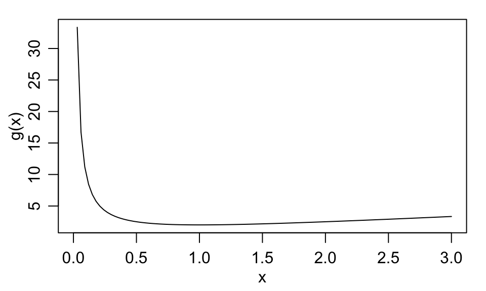

This looks convex. Let’s take a derivative and see where it is zero:

$$\begin{align*}
h'(x) = 1 - a/x^2 & = 0 \\
x^2 &= a.
\end{align*}$$

So the only critical point is $x= \sqrt{a}$. The picture suggests that this is the function’s minimum, but that’s not enough for full credit on the calculus quiz. Let’s take another derivative:

$$h''(x) = 2a/x^3.$$

That’s positive, so indeed $x=\sqrt{a}$ is the minimum of this function:
$$\begin{align*}
\arg \min_{x>0} x + a/x &= \sqrt{a} \\
\min_{x>0} x + a/x & = 2 \sqrt{a} \\
\end{align*}$$

#### The reparametrization

Now suppose we have a single (scalar) $\beta$ and want to minimize some function $\tilde f(\beta) = f(\beta) + \lambda |\beta|$. Here is one way to do it: Write $\beta=uv$ and find values of $u$ and $v$ that minimize the function

$$\tilde g(u,v) = f(uv) + \lambda u^2/2 + \lambda v^2/2.$$

Let’s see why this works:
$$\begin{align*}
\min_{u,v} f(uv) + \lambda u^2/2 + \lambda v^2/2 &=
\min_{\beta,u} f(\beta) + \lambda u^2/2 + \lambda (\beta/u)^2/2
\\
&= \min_\beta f(\beta) +
\tfrac{\lambda}{2} \min_u \left [ u^2 + (\beta/u)^2 \right ] \\
&= \min_\beta f(\beta) +
\tfrac{\lambda}{2} ( 2\sqrt{\beta^2} ) \\
&= \min_\beta f(\beta) + \lambda|\beta|.
\end{align*}$$

The first line follows by letting $\beta= uv$. The third line follows from the calculus result above.

#### The generalization

Now let $\beta$ be a vector, and reparametrize as $\beta=u\circ v$ where “$\circ$” is the Hadamard (elementwise) product of the vectors $u$ and $v$. Applying the same logic as above, it follows that

$$\min_\beta f(\beta) + \lambda \sum |\beta_j| =
\min_{u,v} f(uv) + \lambda u^\top u /2 + \lambda v^\top v/2$$

#### Lasso estimates via alternating ridge regressions

Let’s return to the $L_1$ penalized linear regression problem:
$$\hat \beta = \arg \min_\beta \beta^\top Q \beta - 2 \beta^\top l + \lambda ||\beta||_1$$
As we discussed above, $\hat \beta = \hat u\circ \hat v$ where
$$(\hat u,\hat v) = \arg \min_{u,v} \ (u\circ v)^\top Q (u\circ v) - 2 (u\circ v )^\top l + \tfrac{\lambda}{2}u^\top u + \tfrac{\lambda}{2}v^\top v .$$
The optimal $u$ for fixed $v$ is
$$\begin{align*}
\tilde u & = \arg \min_u
(u\circ v)^\top Q (u\circ v)-2 (u\circ v)^\top l + \tfrac{\lambda}{2}u^\top u \\
& = u^\top (Q \circ v v^\top + I \lambda/2 ) u - 2 u^\top (v\circ l) \\
&= (Q \circ v v^\top + I \lambda/2 )^{-1} (v\circ l).
\end{align*}$$

The third line follows from the second by noting that the second line is equivalent to the ridge regression criterion where $u$ is the parameter. A similar result holds for the optimal value of $v$ given $u$. An alternating ridge regression algorithm for finding the lasso estimate $\hat \beta = \hat u\circ \hat v$ is therefore to iterate the following until convergence.

1. Set $u =(Q \circ v v^\top + I \lambda/2 )^{-1} (v\circ l)$.
2. Set $v =(Q \circ u u^\top + I \lambda/2 )^{-1} (u\circ l)$.

### Numerical example

Let’s try this out with a numerical example - an analysis of some data on diabetes progression. We’ll hold out the first 100 observations to use as a test set, with which we will evaluate the predictive performance of the estimators we obtain.

```r
load(url("http://www2.stat.duke.edu/~pdh10/Datasets/yX_diabetes"))

y<-yX_diabetes[-(1:100),1]  ; ytest<-yX_diabetes[1:100,1]
X<-yX_diabetes[-(1:100),-1] ; Xtest<-yX_diabetes[1:100,-1]

dim(X)
```

```
## [1] 342  64
```

```r
colnames(X)
```

```
##  [1] "age"     "sex"     "bmi"     "map"     "tc"      "ldl"     "hdl"
##  [8] "tch"     "ltg"     "glu"     "age^2"   "bmi^2"   "map^2"   "tc^2"
## [15] "ldl^2"   "hdl^2"   "tch^2"   "ltg^2"   "glu^2"   "age:sex" "age:bmi"
## [22] "age:map" "age:tc"  "age:ldl" "age:hdl" "age:tch" "age:ltg" "age:glu"
## [29] "sex:bmi" "sex:map" "sex:tc"  "sex:ldl" "sex:hdl" "sex:tch" "sex:ltg"
## [36] "sex:glu" "bmi:map" "bmi:tc"  "bmi:ldl" "bmi:hdl" "bmi:tch" "bmi:ltg"
## [43] "bmi:glu" "map:tc"  "map:ldl" "map:hdl" "map:tch" "map:ltg" "map:glu"
## [50] "tc:ldl"  "tc:hdl"  "tc:tch"  "tc:ltg"  "tc:glu"  "ldl:hdl" "ldl:tch"
## [57] "ldl:ltg" "ldl:glu" "hdl:tch" "hdl:ltg" "hdl:glu" "tch:ltg" "tch:glu"
## [64] "ltg:glu"
```

First, the OLS estimates:

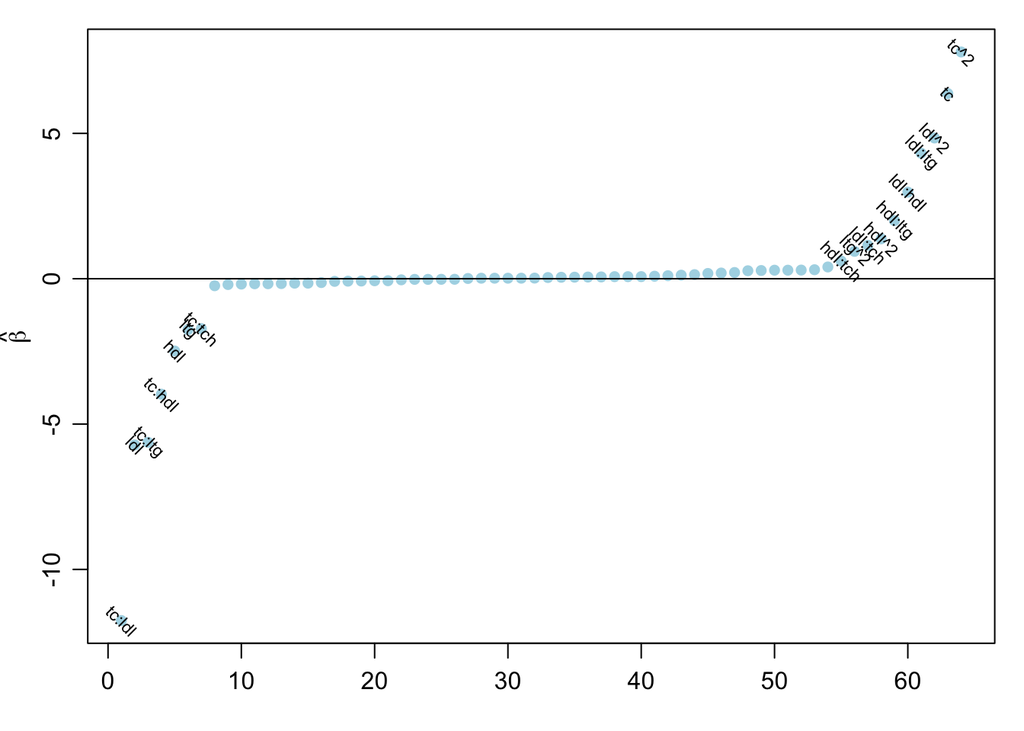

```r
mean( (ytest - Xtest%*%beta_ols)^2 )
```

```
## [1] 0.5966967
```

A lot of the estimated coefficients are close to zero, but of course not quite zero. We could just infer that these estimated effects are “small”, but that doesn’t sound very sophisticated. Instead, let’s use the Hadamard product parametrization to obtain sparse lasso estimates. Here is the code to set up the algorithm:

```r
Q<-crossprod(X)
l<-crossprod(X,y)

Il<-diag(ncol(X))*lambda
v<-sqrt(abs(fit_ols$coef))
```

The object `Il` is just a diagonal matrix times the penalty parameter $\lambda$. What is the value of $\lambda$ and where did it come from? The value is 14.26, and this is a moment-based empirical Bayes estimate. Here is the optimization algorithm:

```r
for(s in 1:100)
{
  u<- solve( Q * v%*%t(v) + Il/2 )%*%( l*v )

  v<- solve( Q * u%*%t(u) + Il/2 )%*%( l*u )
}

beta_l1p<-u*v
```

Here are the resulting lasso estimates. As can be seen, many of the estimated coefficients are zero.

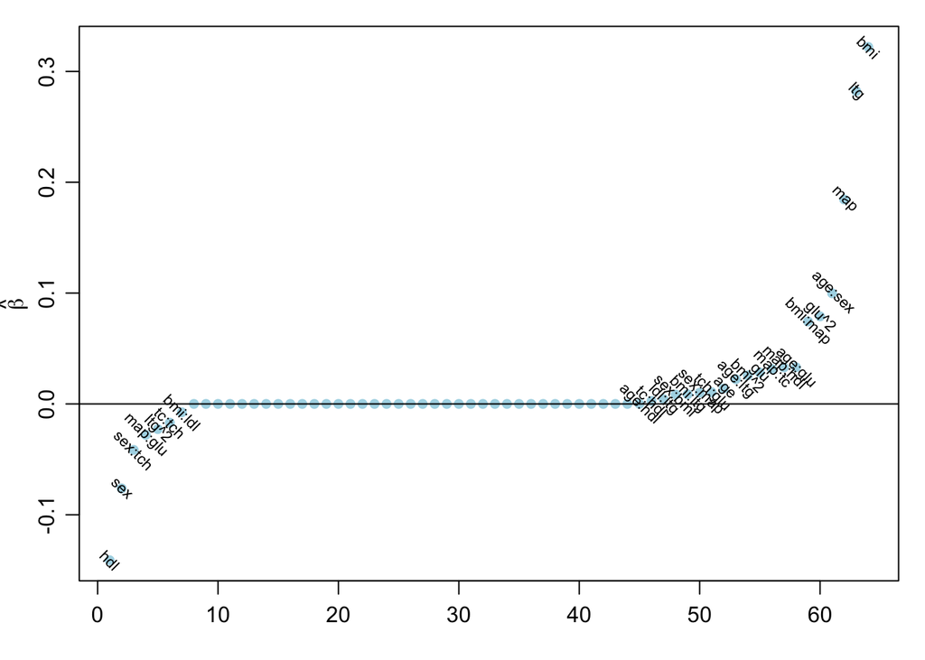

The resulting sparse estimate provide slightly improved predictive performance, as compared to the OLS estimate:

```r
mean( (ytest - Xtest%*%beta_l1p)^2 )
```

```
## [1] 0.5337473
```

Still, there are a lot of coefficient estimates that are small, but not quite zero. Can’t we zap these away too?

We’ve seen how writing $\beta = u\circ v$ leads to penalized (lasso) estimates of $\beta$. Maybe to get more penalization we could write $\beta$ as a product of more things:

```r
v<-w<-x<-(abs(beta_ols))^(.25)

for(s in 1:100)
{
  u<- solve( Q * (v*w*x)%*%t(v*w*x) + Il/4 )%*%( l*v*w*x )

  v<- solve( Q * (u*w*x)%*%t(u*w*x) + Il/4 )%*%( l*u*w*x )

  w<- solve( Q * (u*v*x)%*%t(u*v*x) + Il/4 )%*%( l*u*v*x )

  x<- solve( Q * (u*v*w)%*%t(u*v*w) + Il/4 )%*%( l*u*v*w )
}

beta_lhp<-u*v*w*x
```

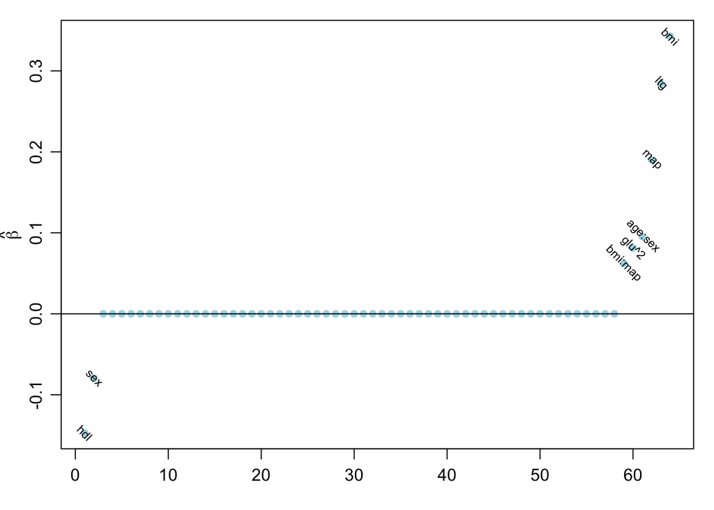

Indeed, this has led to a “stronger” penalty in the sense that now we have mostly coefficients that are zero, and a few coefficients that are reasonably far from zero. This is very aesthetically pleasing, and even better, leads to improved predictive performance:

```r
mean( (ytest - Xtest%*%beta_lhp)^2 )
```

```
## [1] 0.5187066
```

What is this crazy estimate, that was obtained by writing $\beta$ as the Hadamard product of four quantities? In fact, you can show that the resulting estimate `beta_lhp` is a local minimizer of the $L_{1/2}$-penalized residual sum of squares:

$$\hat \beta_{1/2} =
\arg \min ||y-X\beta||^2 + \lambda ||\beta||_{1/2}.$$

This penalty is non-convex, and allows for more shrinkage of the small coefficients without biasing the larger coefficients as much. More on the correspondence between this penalty and the Hadamard product parametrization can be found in my article [arXiv:1611.00040](https://arxiv.org/abs/1611.00040). The article also includes

- a comparison to other optimization methods;
- an algorithm for penalized logistic regression;
- an new penalty for spatially structured sparsity.